# Subjective and autonomic nervous system responses to affective pictures in people with frequent nightmares

# Aims

Theories suggest that people with frequent nightmares may have disturbed emotional processing, however this claim has not been supported by experimental evidence. This research investigates the following claims: People with frequent nightmares…  
A) …have a heightened reactivity to disturbing stimuli  
B) …have a slower habituation to disturbing stimuli

# Methods

Data was collected from participants with and without frequent nightmares. After a first accommodating night, participants were exposed to neutral and negative IAPS pictures in three blocks, while skin conductance and electrocardiogram was recorded. Arousal and valence of the pictures were evaluated after exposure. Subsequently, participant spent a night at the sleep lab, and took part in a recall session in the morning when where New pictures were shown along with the original ones.

# Data analysis strategy

- We use linear mixed-effects modeling using the lme4 package
- The random structure is determined by the Zuur (2009) method to determine the random and fixed structure
- Outcome variables are **subjective arousal, valence, skin conductance response (SCR), and heart rate deceleration (HRD)** (see processing details for each outcome measure below)
- We used **group** (control/nightmare) **block** (1/2/3) **picture** (neutral/negative) variables as fixed effects
- We start with a full model, and remove effects sequentially that does not contribute to the model
- Model comparisons are based on BIC: difference that are larger than 2 are considered important.

## Participant info (TBA)

- Table about the average age, gender by group
- Differences between groups in gender, age, and psych scales
- Put subjective, scr, hrd data into one dataset (?)

## Prepare data

```r
all_data <-
    participants %>%
    left_join(scr_data, by = "id") %>%
    left_join(hrd_data, by = c("id", "session", "block", "stimulus")) %>%
    left_join(markers_wo_time, by = c("id", "session", "stimulus", "block")) %>%
    # Remove outliers larger that 3.5 sds
    filter(abs(scr_std) < 3.5 & abs(hrd_std) < 3.5) %>%
    # Add whether a picture in the recall session is New or Old, a block is Pre-sleep or Post-sleep, and set factor levels
    mutate(novelty = case_when(
               session == "recall" & pic_set == "A" & stimulus %in% set_a ~ "Old",
               session == "recall" & pic_set == "A" & !(stimulus %in% set_a) ~ "New",
               session == "recall" & pic_set == "B" & stimulus %in% set_b ~ "Old",
               session == "recall" & pic_set == "B" & !(stimulus %in% set_b) ~ "New",
               TRUE ~ NA_character_) %>%
                   factor(., levels = c("Old", "New")),
            sleep = case_when(
                block == 3 ~ "Pre-sleep",
                session == "recall" & novelty == "Old" ~ "Post-sleep",
                TRUE ~ NA_character_) %>%
                   factor(levels = c("Pre-sleep", "Post-sleep")),
            block = if_else(session == "recall", NA_integer_, block),
            picture = factor(picture, levels = c("Neutral", "Negative"))
    )
# Create a df where data is aggregated for participants by session, block, group, etc.
df_sum <-
    all_data %>%
    group_by(id, session, block, group, picture, novelty, sleep) %>%
    summarise(scr = mean(scr_sqrt, na.rm = TRUE),
              hrd = mean(hrd, na.rm = TRUE),
              arousal = mean(arousal, na.rm = TRUE),
              valence = mean(valence, na.rm = TRUE)) %>%
    ungroup()
# This dataset is needed for the model that contains sleeping
sleep_df <-
    df_sum %>%
    drop_na(sleep) %>%
    select(-session, -block, -novelty)
# Dataset for plotting the sleep data
sleep_plot_df <-
    all_data %>%
    drop_na(sleep) %>%
    group_by(group, picture, sleep) %>%
    summarise(scr_mean = mean(scr_sqrt, na.rm = TRUE),
              scr_se = sd(scr_sqrt, na.rm = TRUE)/sqrt(n()),
              hrd_mean = mean(hrd, na.rm = TRUE),
              hrd_se = sd(hrd, na.rm = TRUE)/sqrt(n()),
              arousal_mean = mean(arousal, na.rm = TRUE),
              arousal_se = sd(arousal, na.rm = TRUE)/sqrt(n()),
              valence_mean = mean(valence, na.rm = TRUE),
              valence_se = sd(valence, na.rm = TRUE)/sqrt(n())) %>%
    ungroup()
skimr::skim(df_sum)
```

```
Skim summary statistics
 n obs: 336
 n variables: 11

-- Variable type:character -----------------------------------------------------
 variable missing complete   n min max empty n_unique
    group       0      336 336   7   9     0        2
       id       0      336 336   2   2     0       36
  session       0      336 336   4   6     0        2

-- Variable type:factor --------------------------------------------------------
 variable missing complete   n n_unique                top_counts ordered
  novelty     200      136 336        2 NA: 200, Old: 68, New: 68   FALSE
  picture       0      336 336        2 Neu: 168, Neg: 168, NA: 0   FALSE
    sleep     202      134 336        2 NA: 202, Pos: 68, Pre: 66   FALSE

-- Variable type:integer -------------------------------------------------------
 variable missing complete   n mean   sd p0 p25 p50 p75 p100     hist
    block     136      200 336 1.99 0.82  1   1   2   3    3 ▇▁▁▇▁▁▁▇

-- Variable type:numeric -------------------------------------------------------
 variable missing complete   n   mean   sd    p0   p25   p50   p75  p100
  arousal       0      336 336  5.25  2.3    1    3.1   5.25  7.56  8.9
      hrd       0      336 336 -2.89  1.6  -11.6 -3.57 -2.58 -1.82 -0.19
      scr       0      336 336 -0.073 0.43  -1   -0.39 -0.12  0.18  1.53
  valence       0      336 336  4.29  1.95   1.1  2.48  4.25  6.03  8.2
     hist
 ▂▆▆▃▂▃▇▅
 ▁▁▁▁▂▅▇▃
 ▁▆▇▆▃▁▁▁
 ▅▇▅▂▃▇▅▁
```

# Subjective arousal

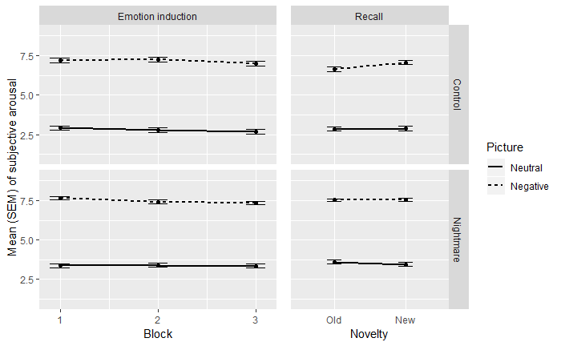

## Emotion habituation model (arousal)

```r
arousal_lm <- lm(arousal ~ group * block * picture, data = df_sum)
arousal_i <- lmer(arousal ~ group * block * picture + (1 | id), data = df_sum)
arousal_is <- lmer(arousal ~ group * block * picture + (group : picture | id), data = df_sum)
```

[output not shown]

```r
# Remove 3 way interaction
arousal_best <- arousal_i
# Note that we use the random intercept model, however the random intercept+slope model may have a better fit (although it fails to converge properly). The optimal random structure is yet to be found.
arousal_3 <- update(arousal_best, . ~ . - group : block : picture)
arousal_best <- arousal_3
# Remove 2-way interactions
arousal_2_1 <- update(arousal_best, . ~ . - group : block) # Drop
arousal_2_2 <- update(arousal_best, . ~ . - group : picture) # Drop
arousal_2_3 <- update(arousal_best, . ~ . - block : picture) # Drop
arousal_best <- update(arousal_best, . ~ . - group:block - group:picture - block:picture)
# We keep all main effects
summary(arousal_best)
```

```
Linear mixed model fit by REML. t-tests use Satterthwaite's method [
lmerModLmerTest]
Formula: arousal ~ group + block + picture + (1 | id)
   Data: df_sum

REML criterion at convergence: 501.3

Scaled residuals:
     Min       1Q   Median       3Q      Max
-2.15978 -0.66714  0.00722  0.60650  2.62511

Random effects:
 Groups   Name        Variance Std.Dev.
 id       (Intercept) 0.4607   0.6788
 Residual             0.5112   0.7150
Number of obs: 200, groups:  id, 34

Fixed effects:
                 Estimate Std. Error        df t value Pr(>|t|)
(Intercept)       3.07237    0.23832  65.00209  12.892   <2e-16 ***
groupNightmare    0.44554    0.25880  32.45284   1.722   0.0947 .
block            -0.09719    0.06207 165.68224  -1.566   0.1193
pictureNegative   4.19919    0.10112 164.39967  41.529   <2e-16 ***
---
Signif. codes:  0 ‘***’ 0.001 ‘**’ 0.01 ‘*’ 0.05 ‘.’ 0.1 ‘ ’ 1

Correlation of Fixed Effects:
            (Intr) grpNgh block
groupNghtmr -0.636
block       -0.507 -0.013
pictureNgtv -0.212  0.000  0.000
```

- There is a clear and strong effect of the picture type as negative pictures are associated with a higher subjective arousal compared to the neutral pictures.

## Sleep habituation model (arousal)

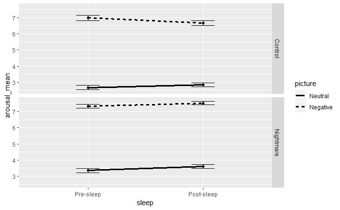

```r
sleep_plot_df %>%
    ggplot() +
    aes(x = sleep, y = arousal_mean, ymin = arousal_mean - arousal_se, ymax = arousal_mean + arousal_se, group = picture) +
    geom_point() +
    geom_line(aes(linetype = picture), size = 1.2) +
    geom_errorbar(width = .2) +
    facet_grid(group ~ .)
```

```r
lmer(arousal ~ group * picture * sleep + (1 | id), data = sleep_df) %>%
    summary()
```

```
Linear mixed model fit by REML. t-tests use Satterthwaite's method [
lmerModLmerTest]
Formula: arousal ~ group * picture * sleep + (1 | id)
   Data: sleep_df

REML criterion at convergence: 376.1

Scaled residuals:
     Min       1Q   Median       3Q      Max
-2.01276 -0.60622 -0.02079  0.63071  2.27625

Random effects:
 Groups   Name        Variance Std.Dev.
 id       (Intercept) 0.5321   0.7295
 Residual             0.6725   0.8201
Number of obs: 134, groups:  id, 36

Fixed effects:
                                               Estimate Std. Error       df
(Intercept)                                     2.65798    0.29890 90.80847
groupNightmare                                  0.69242    0.38575 88.57302
pictureNegative                                 4.33846    0.32166 92.79447
sleepPost-sleep                                 0.20475    0.32153 96.34087
groupNightmare:pictureNegative                 -0.35902    0.41317 92.79447
groupNightmare:sleepPost-sleep                  0.03352    0.41436 95.53768
pictureNegative:sleepPost-sleep                -0.52973    0.44669 92.79447
groupNightmare:pictureNegative:sleepPost-sleep  0.44515    0.57796 92.79447
                                               t value Pr(>|t|)
(Intercept)                                      8.892 5.39e-14 ***
groupNightmare                                   1.795   0.0761 .
pictureNegative                                 13.488  < 2e-16 ***
sleepPost-sleep                                  0.637   0.5258
groupNightmare:pictureNegative                  -0.869   0.3871
groupNightmare:sleepPost-sleep                   0.081   0.9357
pictureNegative:sleepPost-sleep                 -1.186   0.2387
groupNightmare:pictureNegative:sleepPost-sleep   0.770   0.4431
---
Signif. codes:  0 ‘***’ 0.001 ‘**’ 0.01 ‘*’ 0.05 ‘.’ 0.1 ‘ ’ 1

Correlation of Fixed Effects:
            (Intr) grpNgh pctrNg slpPs- grpN:N grN:P- pcN:P-
groupNghtmr -0.775
pictureNgtv -0.538  0.417
slepPst-slp -0.563  0.436  0.500
grpNghtmr:N  0.419 -0.536 -0.778 -0.389
grpNghtm:P-  0.437 -0.552 -0.388 -0.776  0.499
pctrNgtv:P-  0.387 -0.300 -0.720 -0.695  0.561  0.539
grpNgh:N:P- -0.299  0.383  0.557  0.537 -0.715 -0.697 -0.773
```

# Subjective valence

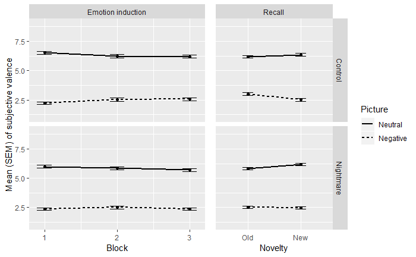

## Emotion habituation model (valence)

```r
valence_lm <- lm(valence ~ group * block * picture, data = df_sum)
valence_i <- lmer(valence ~ group * block * picture + (1 | id), data = df_sum)
valence_is <- lmer(valence ~ group * block * picture + (block : picture | id), data = df_sum)
# Remove 3 way interaction
valence_best <- valence_i
# Note that we use the random intercept model, however the random intercept+slope model may have a better fit (although it fails to converge properly). The optimal random structure is yet to be found.
valence_3 <- update(valence_best, . ~ . - group : block : picture)
valence_best <- valence_3
# Remove 2-way interactions
valence_2_1 <- update(valence_best, . ~ . - group : block) # Drop
valence_2_2 <- update(valence_best, . ~ . - group : picture) # Drop
valence_2_3 <- update(valence_best, . ~ . - block : picture) # Keep
valence_best <- update(valence_best, . ~ . - group:block - group:picture)
# We keep all main effects
summary(valence_best)
```

```
Linear mixed model fit by REML. t-tests use Satterthwaite's method [
lmerModLmerTest]
Formula: valence ~ group + block + picture + (1 | id) + block:picture
   Data: df_sum

REML criterion at convergence: 438.7

Scaled residuals:
     Min       1Q   Median       3Q      Max
-2.25565 -0.74634  0.01922  0.71410  2.15995

Random effects:
 Groups   Name        Variance Std.Dev.
 id       (Intercept) 0.1195   0.3457
 Residual             0.4241   0.6512
Number of obs: 200, groups:  id, 34

Fixed effects:
                       Estimate Std. Error        df t value Pr(>|t|)
(Intercept)             6.50526    0.20215 160.41563  32.180   <2e-16 ***
groupNightmare         -0.25347    0.15338  32.27244  -1.653   0.1081
block                  -0.15565    0.07968 164.29801  -1.953   0.0525 .
pictureNegative        -4.06318    0.24212 163.40905 -16.782   <2e-16 ***
block:pictureNegative   0.22967    0.11252 163.40905   2.041   0.0428 *
---
Signif. codes:  0 ‘***’ 0.001 ‘**’ 0.01 ‘*’ 0.05 ‘.’ 0.1 ‘ ’ 1

Correlation of Fixed Effects:
            (Intr) grpNgh block  pctrNg
groupNghtmr -0.443
block       -0.778 -0.011
pictureNgtv -0.599  0.000  0.653
blck:pctrNg  0.554  0.000 -0.706 -0.925
```

- There is a clear and strong effect of the picture type as negative pictures are associated with a lower subjective valence compared to the neutral pictures. ## Sleep habituation model (valence)

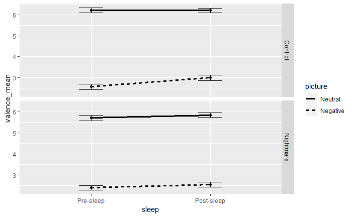

```r
sleep_plot_df %>%
    ggplot() +
    aes(x = sleep, y = valence_mean, ymin = valence_mean - valence_se, ymax = valence_mean + valence_se, group = picture) +
    geom_point() +
    geom_line(aes(linetype = picture), size = 1.2) +
    geom_errorbar(width = .2) +
    facet_grid(group ~ .)
```

```r
lmer(valence ~ group * picture * sleep + (1 | id), data = sleep_df) %>%
    summary()
```

```
Linear mixed model fit by REML. t-tests use Satterthwaite's method [
lmerModLmerTest]
Formula: valence ~ group * picture * sleep + (1 | id)
   Data: sleep_df

REML criterion at convergence: 320.5

Scaled residuals:
    Min      1Q  Median      3Q     Max
-1.9839 -0.6527 -0.0556  0.7795  2.0953

Random effects:
 Groups   Name        Variance Std.Dev.
 id       (Intercept) 0.1304   0.3611
 Residual             0.5236   0.7236
Number of obs: 134, groups:  id, 36

Fixed effects:
                                                Estimate Std. Error        df
(Intercept)                                      6.22294    0.22330 116.45688
groupNightmare                                  -0.51107    0.28715 115.44170
pictureNegative                                 -3.64103    0.28381  90.37128
sleepPost-sleep                                 -0.04715    0.28134  95.55714
groupNightmare:pictureNegative                   0.33214    0.36456  90.37128
groupNightmare:sleepPost-sleep                   0.18621    0.36325  94.39284
pictureNegative:sleepPost-sleep                  0.44261    0.39413  90.37128
groupNightmare:pictureNegative:sleepPost-sleep  -0.43067    0.50995  90.37128
                                               t value Pr(>|t|)
(Intercept)                                     27.868   <2e-16 ***
groupNightmare                                  -1.780   0.0777 .
pictureNegative                                -12.829   <2e-16 ***
sleepPost-sleep                                 -0.168   0.8673
groupNightmare:pictureNegative                   0.911   0.3647
groupNightmare:sleepPost-sleep                   0.513   0.6094
pictureNegative:sleepPost-sleep                  1.123   0.2644
groupNightmare:pictureNegative:sleepPost-sleep  -0.845   0.4006
---
Signif. codes:  0 ‘***’ 0.001 ‘**’ 0.01 ‘*’ 0.05 ‘.’ 0.1 ‘ ’ 1

Correlation of Fixed Effects:
            (Intr) grpNgh pctrNg slpPs- grpN:N grN:P- pcN:P-
groupNghtmr -0.778
pictureNgtv -0.635  0.494
slepPst-slp -0.657  0.511  0.504
grpNghtmr:N  0.495 -0.635 -0.778 -0.393
grpNghtm:P-  0.509 -0.649 -0.391 -0.775  0.502
pctrNgtv:P-  0.458 -0.356 -0.720 -0.700  0.561  0.543
grpNgh:N:P- -0.354  0.454  0.557  0.541 -0.715 -0.702 -0.773
```

# Skin Conductance Response (SCR)

## Data processing

- Skin conductance was recorded using a sampling rate of 32 Hz
- Ledalab toolbox was used to down-sample data to 16 Hz, use continuous decomposition analysis with optimized parameters to separate tonic (SCL) and phasic (SCR) skin conductance. SCR was calculated using a response window of 1 to 4 sec after stimuli presentation, with a minimum amplitude threshOld criterion of 0.01 muS.
- SCR was square root transformed and scaled for each participant

## Exploratory data analysis on data quality

### Number of markers/participants in the data analysis

Most data can be matched to markers. However … - all recordings are missing for 41, 43, and 54.

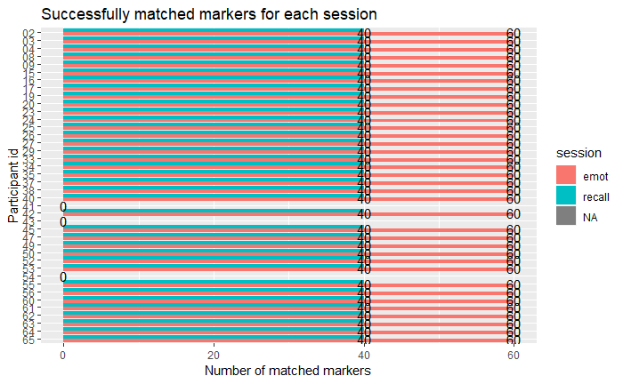

```r
participants %>%
    left_join(scr_data, by = "id") %>%
    arrange(id, session) %>%
    mutate(id = as_factor(id),
           session = as_factor(session)) %>%
    group_by(id, session) %>%
    count() %>%
    mutate(n = if_else(n == 1, 0L, n)) %>%
    ggplot() +
    aes(x = fct_rev(id),
        y = n,
        fill = session,
        label = n) +
    geom_col(position = "dodge") +
    geom_text() +
    coord_flip() +
    labs(title = "Successfully matched markers for each session",
         y = "Number of matched markers",
         x = "Participant id")
```

## Emotion habituation model (SCR)

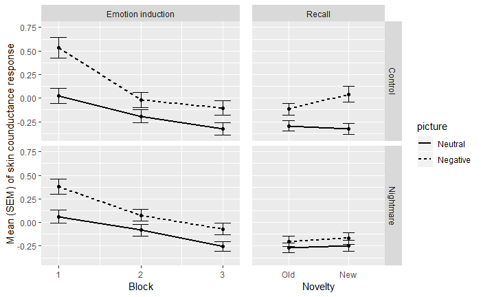

```r
# Using Zuur method to select random structure
# Simple linear regression to justify lmer
model_lm <- lm(scr ~ group * block * picture, data = df_sum)
# Random intercept
model_i <- lmer(scr ~ group * block * picture + (1 | id), data = df_sum)
# Random intercept and splope
model_is <- lmer(scr ~ group * block * picture + (block : picture | id), data = df_sum)
# anova(model_i, model_lm)
# anova(model_i, model_is)
# The random intercept model is the best
#summary(model_i)
# Remove 3 way interaction
model_best <- model_i
model_3 <- update(model_best, . ~ . - group : block : picture)
# anova(model_best, model_3)
model_best <- model_3  # Drop 3-way interaction
#summary(model_best)
# Remove 2-way interactions
model_2_1 <- update(model_best, . ~ . - group : block)
model_2_2 <- update(model_best, . ~ . - group : picture)
model_2_3 <- update(model_best, . ~ . - block : picture)
# anova(model_best, model_2_1) # Drop
# anova(model_best, model_2_2) # Drop
# anova(model_best, model_2_3) # Keep
model_best <- update(model_best, . ~ . - group:block - group:picture)
# Remove main effects
# Remove 2-way interactions
model_1_1 <- update(model_best, . ~ . - block)
model_1_2 <- update(model_best, . ~ . - group)
model_1_3 <- update(model_best, . ~ . - picture)
# anova(model_best, model_1_1) # Can't remove
# anova(model_best, model_1_2) # Drop
# anova(model_best, model_1_3) # Keep
model_best <- update(model_best, . ~ . - group)
summary(model_best)
```

```
Linear mixed model fit by REML. t-tests use Satterthwaite's method [
lmerModLmerTest]
Formula: scr ~ block + picture + (1 | id) + block:picture
   Data: df_sum

REML criterion at convergence: 205

Scaled residuals:
    Min      1Q  Median      3Q     Max
-2.6049 -0.5871 -0.0175  0.5879  3.1953

Random effects:
 Groups   Name        Variance Std.Dev.
 id       (Intercept) 0.02167  0.1472
 Residual             0.13632  0.3692
Number of obs: 200, groups:  id, 34

Fixed effects:
                       Estimate Std. Error        df t value Pr(>|t|)
(Intercept)             0.20159    0.10031 194.18676   2.010 0.045836 *
block                  -0.16032    0.04515 164.15666  -3.551 0.000502 ***
pictureNegative         0.48982    0.13727 163.23294   3.568 0.000472 ***
block:pictureNegative  -0.11430    0.06380 163.23294  -1.792 0.075038 .
---
Signif. codes:  0 ‘***’ 0.001 ‘**’ 0.01 ‘*’ 0.05 ‘.’ 0.1 ‘ ’ 1

Correlation of Fixed Effects:
            (Intr) block  pctrNg
block       -0.895
pictureNgtv -0.684  0.653
blck:pctrNg  0.633 -0.706 -0.925
```

- There was no main or interaction effect of nightmare group membership on SCR
- SCR decreased in each subsequent block, showing signs of habituation
- Negative pictures were associated with larger SCR

## Sleep habituation model (SCR)

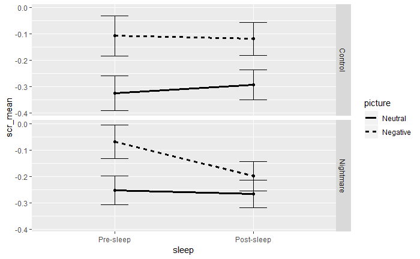

```r
sleep_plot_df %>%
    ggplot() +
    aes(x = sleep, y = scr_mean, ymin = scr_mean - scr_se, ymax = scr_mean + scr_se, group = picture) +
    geom_point() +
    geom_line(aes(linetype = picture), size = 1.2) +
    geom_errorbar(width = .2) +
    facet_grid(group ~ .)
```

```r
lmer(scr ~ group * picture * sleep + (1 | id), data = sleep_df) %>%
    summary()
```

```
Linear mixed model fit by REML. t-tests use Satterthwaite's method [
lmerModLmerTest]
Formula: scr ~ group * picture * sleep + (1 | id)
   Data: sleep_df

REML criterion at convergence: 102.9

Scaled residuals:
     Min       1Q   Median       3Q      Max
-1.99726 -0.71190 -0.02433  0.61677  2.89616

Random effects:
 Groups   Name        Variance Std.Dev.
 id       (Intercept) 0.0000   0.0000
 Residual             0.1109   0.3331
Number of obs: 134, groups:  id, 36

Fixed effects:
                                                Estimate Std. Error        df
(Intercept)                                     -0.32477    0.09238 126.00000
groupNightmare                                   0.07294    0.11867 126.00000
pictureNegative                                  0.22200    0.13065 126.00000
sleepPost-sleep                                  0.03449    0.12829 126.00000
groupNightmare:pictureNegative                  -0.03902    0.16782 126.00000
groupNightmare:sleepPost-sleep                  -0.04663    0.16599 126.00000
pictureNegative:sleepPost-sleep                 -0.04792    0.18143 126.00000
groupNightmare:pictureNegative:sleepPost-sleep  -0.07028    0.23475 126.00000
                                               t value Pr(>|t|)
(Intercept)                                     -3.516 0.000611 ***
groupNightmare                                   0.615 0.539873
pictureNegative                                  1.699 0.091735 .
sleepPost-sleep                                  0.269 0.788512
groupNightmare:pictureNegative                  -0.233 0.816494
groupNightmare:sleepPost-sleep                  -0.281 0.779240
pictureNegative:sleepPost-sleep                 -0.264 0.792115
groupNightmare:pictureNegative:sleepPost-sleep  -0.299 0.765156
---
Signif. codes:  0 ‘***’ 0.001 ‘**’ 0.01 ‘*’ 0.05 ‘.’ 0.1 ‘ ’ 1

Correlation of Fixed Effects:
            (Intr) grpNgh pctrNg slpPs- grpN:N grN:P- pcN:P-
groupNghtmr -0.778
pictureNgtv -0.707  0.550
slepPst-slp -0.720  0.561  0.509
grpNghtmr:N  0.550 -0.707 -0.778 -0.396
grpNghtm:P-  0.557 -0.715 -0.394 -0.773  0.506
pctrNgtv:P-  0.509 -0.396 -0.720 -0.707  0.561  0.547
grpNgh:N:P- -0.394  0.506  0.557  0.547 -0.715 -0.707 -0.773
```

Finding: There was no evidence for a difference in SCR before and after sleep.

# Heart rate deceleration (HRD)

## Exploratory data analysis on data quality

### Number of artifacts in the IBI data

First we check the percentage of artifacts in each recording. According to the following plot, the number of corrected artifacts in the sample was low (<3%).

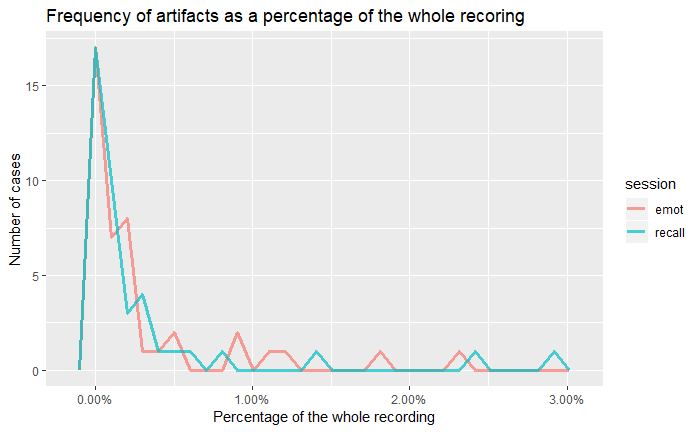

```r
ibi <-
tibble(artifact_file = dir_ls(path = "all_data/artifact_corrected_ibi_berntson/", regexp = "IBI_artifacts_IBIs_from_"),
       corrected_file = dir_ls(path = "all_data/artifact_corrected_ibi_berntson/", regexp = "IBI_artifactCorrected_IBIs_from_")
       ) %>%
    transmute(id = str_extract(artifact_file, "\\d+"),
              session = str_replace(artifact_file, ".*_\\d+_(\\w+)_ECG.txt.csv$", "\\1"),
              artifact_data = map(artifact_file, ~read_csv(.x, col_types = "di")),
              corrected_data = map(corrected_file, ~read_csv(.x, col_types = "d")),
              data = map2(artifact_data,
                          corrected_data,
                          ~bind_cols(.x, .y))
                      ) %>%
    unnest(data) %>%
    rename(ibi = IBI, ibi_corrected = IBI_artefactCorrected)
ibi %>%
    group_by(id, session) %>%
    summarise(artifact_n = sum(artifact),
              artifact_p = sum(artifact)/n()) %>%
    ggplot() +
    aes(x = artifact_p, color = session, fill = session) +
    scale_x_continuous(labels = scales::percent_format()) +
    geom_freqpoly(size = 1.3, alpha = .7) +
    labs(title = "Frequency of artifacts as a percentage of the whole recoring",
         y = "Number of cases",
         x = "Percentage of the whole recording")
```

### Number of markers/participants in the data analysis

Most data can be matched to markers. However … - all recordings are missing for 26, 41, 43 and 54. - the complete session of emot is missing for 04, 42; and recall is missing for 33, 34. - participant 47 has only 6 successfully matched markers in the emot session.

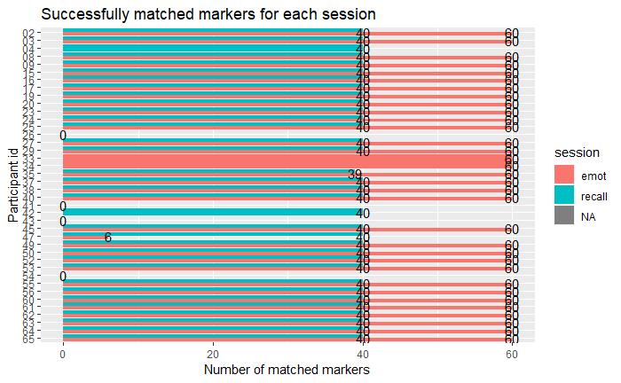

```r
participants %>%
    left_join(hrd_data, by = "id") %>%
    mutate(id = as_factor(id),
           session = as_factor(session)) %>%
    group_by(id, session) %>%
    count() %>%
    mutate(n = if_else(n == 1, 0L, n)) %>%
    ggplot() +
    aes(x = fct_rev(id),
        y = n,
        fill = session,
        label = n) +
    geom_col(position = "dodge") +
    geom_text() +
    coord_flip() +
    labs(title = "Successfully matched markers for each session",
         y = "Number of matched markers",
         x = "Participant id")
```

```r
# Nudge data points to the closest half second. This decreases marker accuracy somewhat (from perfect accuracy, they become quarter-of-a-second accurate, which should be enough if we consider that HRD is calculated in a 3 second window)
markers_hrd <-
    markers %>%
    select(id, session, block, stimulus, time, picture) %>%
    mutate(time = plyr::round_any(time,.5),
           block = if_else(session == "recall", NA_integer_, block)) %>%
    arrange(id, session, time)
hr_6s <-
    hr_data %>%
    # Join markers to the heart rate data
    left_join(markers_hrd,
              by = c("id", "session", "time")) %>%
    group_by(session, id) %>%
    # Fill the missing data (last value carry forward)
    fill(block, stimulus, picture) %>%
    # select(-order, -valence, -arousal, -familiarity) %>%
    group_by(id, session, stimulus, block) %>%
    # Keep only the 6 seconds after stimuli presentation
    slice(0:12) %>%
    # Calculate relative time and heart rate (compared to stimuli presentation)
    mutate(rel_time = time - first(time),
           hr_change = hr - first(hr)) %>%
    ungroup() %>%
    # Join only those that were not excluded from the sample
    right_join(participants, by = "id") %>%
    drop_na(session, block) %>%
    arrange(id, session, block, stimulus, rel_time)
```

## Exploring HR reaction after stimuli presentation

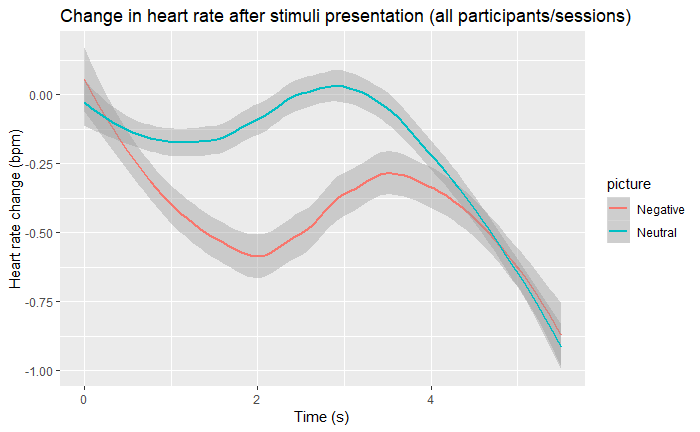

```r
# Change in HR after stimuli presentation (all participants/sessions)
hr_6s %>%
    group_by(picture, rel_time) %>%
    summarise(hr_change = mean(hr_change, na.rm = TRUE)) %>%
    ggplot() +
    aes(x = rel_time, y = hr_change, color = picture) +
    geom_smooth(method = "loess") +
    labs(title = "Change in heart rate after stimuli presentation (all participants/sessions)",
         x = "Time (s)",
         y = "Heart rate change (bpm)")
```

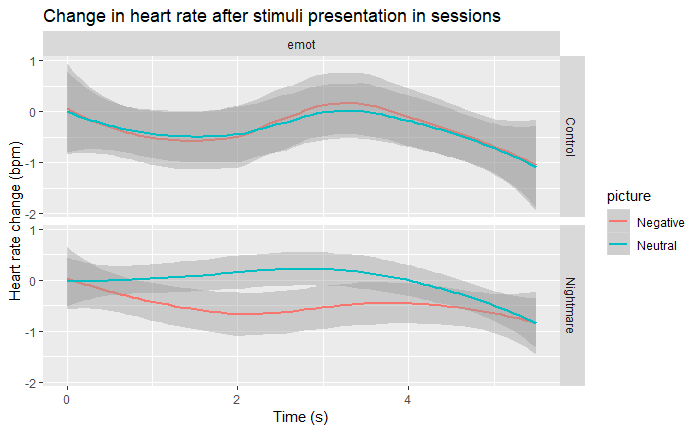

```r
# Change by session
hr_6s %>%
    group_by(id, session, group, picture, rel_time) %>%
    summarise(hr_change = mean(hr_change, na.rm = TRUE)) %>%
    ggplot() +
        aes(x = rel_time, y = hr_change, color = picture) +
        geom_smooth(method = "loess") +
        facet_grid(group~session) +
        labs(title = "Change in heart rate after stimuli presentation in sessions",
             x = "Time (s)",
             y = "Heart rate change (bpm)")
```

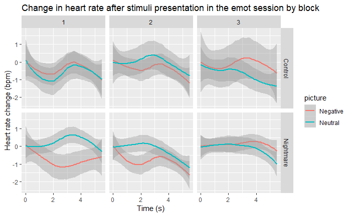

```r
# Change in heart rate after stimuli presentation in the emot session by block
hr_6s %>%
    filter(session == "emot") %>%
    group_by(id, group, picture, rel_time, block) %>%
    summarise(hr_change = mean(hr_change, na.rm = TRUE)) %>%
    arrange(id, block, picture, rel_time) %>% # Just for checking values
    ggplot() +
        aes(x = rel_time, y = hr_change, color = picture) +
        geom_smooth(method = "loess") +
        facet_grid(group~block) +
        labs(title = "Change in heart rate after stimuli presentation in the emot session by block",
             x = "Time (s)",
             y = "Heart rate change (bpm)")
```

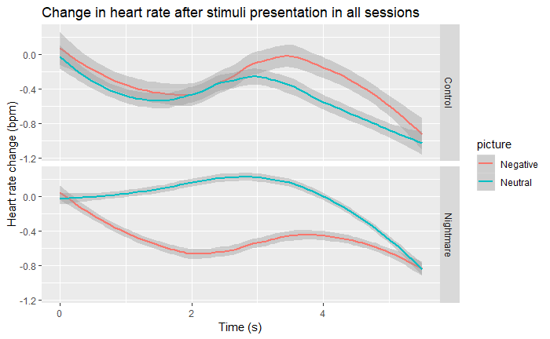

```r
# Change in heart rate after stimuli presentation in all sessions
hr_6s %>%
    group_by(group, picture, rel_time) %>%
    summarise(hr_change = mean(hr_change, na.rm = TRUE)) %>%
    ggplot() +
    aes(x = rel_time, y = hr_change, color = picture) +
    geom_smooth(method = "loess") +
    facet_grid(group ~ .) +
    labs(title = "Change in heart rate after stimuli presentation in all sessions",
         x = "Time (s)",
         y = "Heart rate change (bpm)")
```

## Calculate Hear rate deceleration

The minimum of heart rate after stimuli presentation in a 3 second frame.

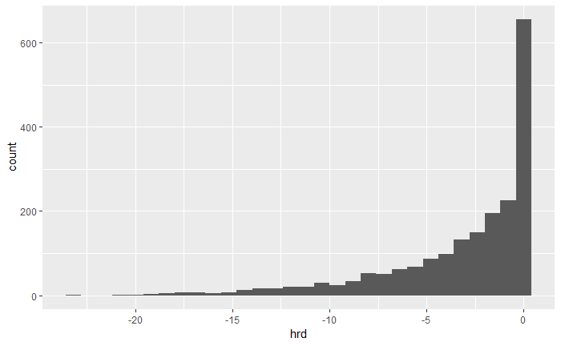

```r
# This block should be moved to a different script
hrd <-
    hr_data %>%
    # Join markers to the heart rate data
    left_join(markers_hrd,
              by = c("id", "session", "time")) %>%
    group_by(session, id) %>%
    # Fill the missing data (last value carry forward)
    fill(block, stimulus, picture) %>%
    group_by(id, session, block, stimulus) %>%
    # Keep only the 6 seconds after stimuli presentation
    slice(0:6) %>%
    # Calculate relative time and heart rate (compared to stimuli presentation)
    mutate(rel_time = time - first(time),
           hr_change = hr - first(hr)) %>%
    group_by(id) %>%
    mutate(hr_change_std = scale(hr_change)) %>%
    ungroup() %>%
    filter(abs(hr_change_std) < 3.5) %>%
    # Join only those that were not excluded from the sample
    right_join(participants, by = "id") %>%
    drop_na(session, block) %>%
    group_by(id, session, block, stimulus, picture, group, gender, pic_set) %>%
    summarise(hrd = min(hr_change, na.rm = TRUE)) %>%
    ungroup() %>%
    mutate(novelty = case_when(
        session == "recall" & pic_set == "A" & stimulus %in% set_a ~ "Old",
        session == "recall" & pic_set == "A" & !(stimulus %in% set_a) ~ "New",
        session == "recall" & pic_set == "B" & stimulus %in% set_b ~ "Old",
        session == "recall" & pic_set == "B" & !(stimulus %in% set_b) ~ "New",
        TRUE ~ NA_character_) %>%
            factor(., levels = c("Old", "New"))) %>%
    mutate(block = case_when(session == "recall" & novelty == "New" ~ NA_integer_,
                             TRUE ~ block)) %>%
    arrange(id, session, block, stimulus)
hrd %>%
    ggplot() +
    aes(x = hrd) +
    geom_histogram()
```

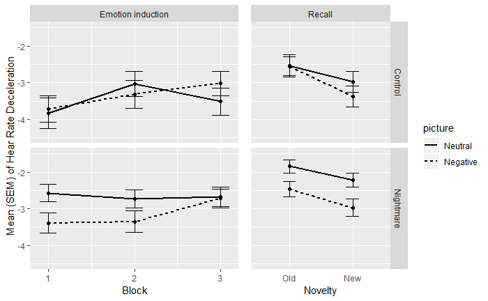

```r
plot_emot_hrd <-
    all_data %>%
    filter(session == "emot") %>%
    mutate(session = case_when(session == "emot" ~ "Emotion induction",
                               session == "recall" ~ "Recall")) %>%
    group_by(session, block, group, picture) %>%
    summarise(Mean = mean(hrd, na.rm = TRUE),
              Se = sd(hrd, na.rm = TRUE)/sqrt(n())) %>%
    ggplot() +
        aes(x = block, y = Mean, group = picture, ymin = Mean - Se, ymax = Mean + Se) +
        geom_point() +
        geom_errorbar(width = .2) +
        geom_line(aes(linetype = picture), size = 1) +
        coord_cartesian(ylim = c(-1.5, -4.5)) +
        scale_x_continuous("Block", breaks = 1:3) +
        scale_y_continuous("Mean (SEM) of Hear Rate Deceleration") +
        guides(linetype = "none") +
        facet_grid(group ~ session) +
        theme(strip.text.y = element_blank()) +
        NULL
plot_recall_hrd <-
    all_data %>%
    filter(session == "recall") %>%
    mutate(session = case_when(session == "emot" ~ "Emotion induction",
                               session == "recall" ~ "Recall")) %>%
    group_by(session, group, picture, novelty) %>%
    summarise(Mean = mean(hrd, na.rm = TRUE),
              Se = sd(hrd, na.rm = TRUE)/sqrt(n())) %>%
    ggplot() +
        aes(x = novelty, y = Mean, group = picture, ymin = Mean - Se, ymax = Mean + Se) +
        geom_point() +
        geom_errorbar(width = .2) +
        geom_line(aes(linetype = picture), size = 1) +
        coord_cartesian(ylim = c(-1.5, -4.5)) +
        scale_x_discrete("Novelty") +
        scale_y_continuous(NULL) +
        facet_grid(group ~ session) +
        theme(axis.text.y = element_blank(),
              axis.ticks = element_blank()) +
        NULL
plot_emot_hrd +
    plot_recall_hrd +
    plot_layout(widths = c(3,2))
```

## Emotion habituation model (HRD)

```r
# Using Zuur method to select random structure
# Make the recall the 4th block
# hrd_emot <-
#     mutate(df_sum, block = if_else(session == "recall", 4L, block))
# Linear regression
hrd_lm <- lm(hrd ~ group * block * picture, data = df_sum)
# Random intercept
hrd_i <- lmer(hrd ~ group * block * picture + (1 | id) , data = df_sum)
# Random intercept and splope
hrd_is <- lmer(hrd ~ group * block * picture + (picture * block | id), data = df_sum)
#anova(hrd_i, hrd_lm)
#anova(hrd_i, hrd_is)
# The random intercept model is the best
#summary(hrd_i)
# Remove 3 way interaction
hrd_best <- hrd_i
hrd_3 <- update(hrd_best, . ~ . - group : block : picture)
#anova(hrd_best, hrd_3)
hrd_best <- hrd_3  # Drop 3-way interaction
#summary(hrd_best)
# Remove 2-way interactions
hrd_2_1 <- update(hrd_best, . ~ . - group : block)
hrd_2_2 <- update(hrd_best, . ~ . - group : picture)
hrd_2_3 <- update(hrd_best, . ~ . - block : picture)
# anova(hrd_best, hrd_2_1) # Drop
# anova(hrd_best, hrd_2_2) # Keep
# anova(hrd_best, hrd_2_3) # Drop
hrd_best <- update(hrd_best, . ~ . - group:block - block : picture)
# summary(hrd_best)
# Remove main effects
# Remove 2-way interactions
hrd_1_1 <- update(hrd_best, . ~ . - block)
hrd_1_2 <- update(hrd_best, . ~ . - group)
hrd_1_3 <- update(hrd_best, . ~ . - picture)
# anova(hrd_best, hrd_1_1) # Can't remove
# anova(hrd_best, hrd_1_2) # Drop
# anova(hrd_best, hrd_1_3) # Keep
hrd_best <- hrd_1_2
summary(hrd_best)
```

```
Linear mixed model fit by REML. t-tests use Satterthwaite's method [
lmerModLmerTest]
Formula: hrd ~ block + picture + (1 | id) + group:picture
   Data: df_sum

REML criterion at convergence: 718.4

Scaled residuals:
    Min      1Q  Median      3Q     Max
-3.6193 -0.6552  0.1659  0.6104  2.5400

Random effects:
 Groups   Name        Variance Std.Dev.
 id       (Intercept) 1.677    1.295
 Residual             1.509    1.228
Number of obs: 200, groups:  id, 34

Fixed effects:
                                Estimate Std. Error        df t value Pr(>|t|)
(Intercept)                     -3.74808    0.44902  65.48804  -8.347 6.69e-12
block                            0.17334    0.10667 164.44612   1.625    0.106
pictureNegative                  0.05516    0.27465 163.29448   0.201    0.841
pictureNeutral:groupNightmare    0.74505    0.51742  41.37028   1.440    0.157
pictureNegative:groupNightmare   0.21627    0.51742  41.37028   0.418    0.678

(Intercept)                    ***
block
pictureNegative
pictureNeutral:groupNightmare
pictureNegative:groupNightmare
---
Signif. codes:  0 ‘***’ 0.001 ‘**’ 0.01 ‘*’ 0.05 ‘.’ 0.1 ‘ ’ 1

Correlation of Fixed Effects:
            (Intr) block  pctrNg pctrNt:N
block       -0.461
pictureNgtv -0.306  0.000
pctrNtrl:gN -0.678 -0.012  0.265
pctrNgtv:gN -0.515 -0.012 -0.265  0.765
```

## Sleep habituation model (HRD)

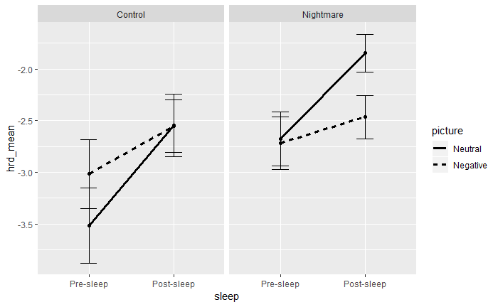

```r
sleep_plot_df %>%
    ggplot() +
    aes(x = sleep, y = hrd_mean, ymin = hrd_mean - hrd_se, ymax = hrd_mean + hrd_se, group = picture) +
    geom_point() +
    geom_line(aes(linetype = picture), size = 1.2) +
    geom_errorbar(width = .2) +
    facet_grid(. ~ group)
```

```r
lmer(hrd ~ group * picture * sleep + (1 | id), data = sleep_df) %>%
    summary()
```

```
Linear mixed model fit by REML. t-tests use Satterthwaite's method [
lmerModLmerTest]
Formula: hrd ~ group * picture * sleep + (1 | id)
   Data: sleep_df

REML criterion at convergence: 458.7

Scaled residuals:
    Min      1Q  Median      3Q     Max
-3.6432 -0.4438  0.0799  0.5652  1.8744

Random effects:
 Groups   Name        Variance Std.Dev.
 id       (Intercept) 0.6816   0.8256
 Residual             1.4220   1.1925
Number of obs: 134, groups:  id, 36

Fixed effects:
                                                Estimate Std. Error        df
(Intercept)                                     -3.45135    0.39803 105.23252
groupNightmare                                   0.80610    0.51265 103.44536
pictureNegative                                  0.43487    0.46773  93.23334
sleepPost-sleep                                  0.90226    0.46582  97.47099
groupNightmare:pictureNegative                  -0.47369    0.60081  93.23334
groupNightmare:sleepPost-sleep                  -0.08281    0.60081  96.51666
pictureNegative:sleepPost-sleep                 -0.44699    0.64955  93.23334
groupNightmare:pictureNegative:sleepPost-sleep  -0.13248    0.84043  93.23334
                                               t value Pr(>|t|)
(Intercept)                                     -8.671 5.69e-14 ***
groupNightmare                                   1.572   0.1189
pictureNegative                                  0.930   0.3549
sleepPost-sleep                                  1.937   0.0556 .
groupNightmare:pictureNegative                  -0.788   0.4325
groupNightmare:sleepPost-sleep                  -0.138   0.8907
pictureNegative:sleepPost-sleep                 -0.688   0.4931
groupNightmare:pictureNegative:sleepPost-sleep  -0.158   0.8751
---
Signif. codes:  0 ‘***’ 0.001 ‘**’ 0.01 ‘*’ 0.05 ‘.’ 0.1 ‘ ’ 1

Correlation of Fixed Effects:
            (Intr) grpNgh pctrNg slpPs- grpN:N grN:P- pcN:P-
groupNghtmr -0.776
pictureNgtv -0.588  0.456
slepPst-slp -0.611  0.475  0.502
grpNghtmr:N  0.457 -0.586 -0.778 -0.391
grpNghtm:P-  0.474 -0.602 -0.389 -0.775  0.500
pctrNgtv:P-  0.423 -0.328 -0.720 -0.697  0.561  0.541
grpNgh:N:P- -0.327  0.419  0.557  0.539 -0.715 -0.699 -0.773
```

# Cortisol

## Data processing

Missing cortisol data (n = 3) was imputed using linear interpolation.

```r
cort_df_raw <-read_csv("analysis_data/cortisol_data.csv")
cort_df <-
    participants %>%
    left_join(cort_df_raw, by = "id") %>%
    group_by(id, day) %>%
    # If the first or last cortisol value is missing, we have to drop it
    drop_na(cortisol) %>%
    # Interpolating cortisol data
    mutate(cortisol_full = approx(x = cort_time,
                                  y = cortisol,
                                  xout = cort_time)$y) %>%
    ungroup() %>%
    mutate(event =  factor(event, levels = c("Night", "Awakening","Awakening +15 min","Awakening +30 min")))
cort_auc <-
    cort_df %>%
    group_by(id, group, day) %>%
    nest() %>%
    mutate(auc = map(data, ~calculate_auc(.x,
                                 time = "cort_time",
                                 measurement = "cortisol_full",
                                 type = "both"))) %>%
    unnest(auc) %>%
    select(-data)
```

## Exploratory data analysis on data quality

### Number of markers/participants in the data analysis

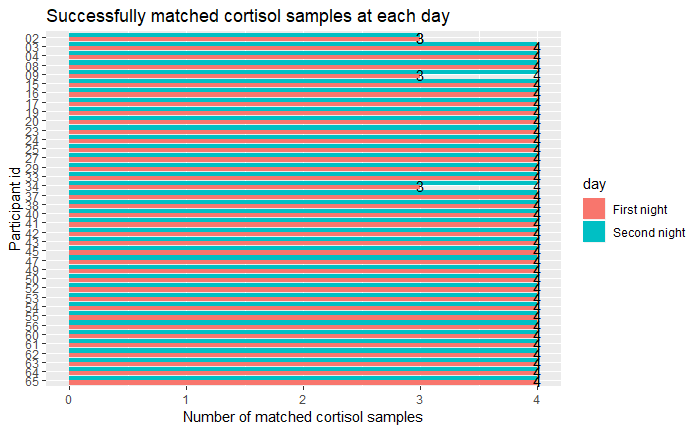

```r
participants %>%
    left_join(cort_df_raw, by = "id") %>%
    mutate(id = as_factor(id),
           day = as_factor(day)) %>%
    group_by(id, day) %>%
    count(cort_missing = is.na(cortisol)) %>%
    filter(!cort_missing) %>%
    mutate(n = if_else(n == 1, 0L, n)) %>%
    ggplot() +
        aes(x = fct_rev(id),
            y = n,
            fill = day,
            label = n) +
        geom_col(position = "dodge") +
        geom_text() +
        coord_flip() +
        labs(title = "Successfully matched cortisol samples at each day",
             y = "Number of matched cortisol samples",
             x = "Participant id")
```

## Cortisol change over time

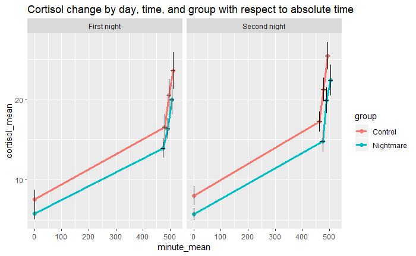

```r
cort_df %>%
    group_by(group, day, cort_time) %>%
    summarise(cortisol_mean = mean(cortisol, na.rm = TRUE),
              cortisol_se = sd(cortisol, na.rm = TRUE)/sqrt(n()),
              minute_mean = mean(cort_minute, na.rm = TRUE),
              minute_se = sd(cort_minute, na.rm = TRUE)/sqrt(n())) %>%
    ggplot() +
    aes(x = minute_mean,
        y = cortisol_mean,
        ymin = cortisol_mean - cortisol_se,
        ymax = cortisol_mean + cortisol_se,
        xmin = minute_mean - minute_se,
        xmax = minute_mean + minute_se,
        group = group) +
    geom_line(aes(color = group), size = 1.2) +
    geom_point(aes(color = group), size = 2) +
    geom_linerange() +
    geom_errorbarh(height = 0) +
    facet_wrap(~day) +
    ggtitle("Cortisol change by day, time, and group with respect to absolute time")
```

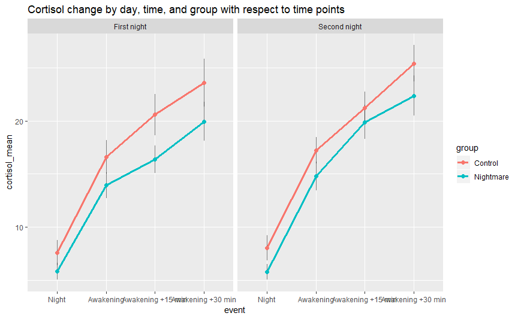

```r
cort_df %>%
    group_by(group, day, cort_time, event) %>%
    summarise(cortisol_mean = mean(cortisol, na.rm = TRUE),
              cortisol_se = sd(cortisol, na.rm = TRUE)/sqrt(n())) %>%
    ggplot() +
    aes(x = event,
        y = cortisol_mean,
        ymin = cortisol_mean - cortisol_se,
        ymax = cortisol_mean + cortisol_se,
        group = group) +
    geom_line(aes(color = group), size = 1.2) +
    geom_linerange(alpha = .5) +
    geom_point(aes(color = group), size = 2) +
    facet_wrap(~day) +
    ggtitle("Cortisol change by day, time, and group with respect to time points")
```

## Area Under the Curve (AUC)

AUC for each participant and each night was calculated with respect to ground (AUCg) and with respect to baseline (AUCi). Linear Mixed-effects models were fitted on the data, with the respective AUC metric as outcome, and group membership (control/nightmare) and day (first/second), and their interaction as predictors. Results were similar if we included the night sample, therefore hereby we only present AUC differences that include the night sample.

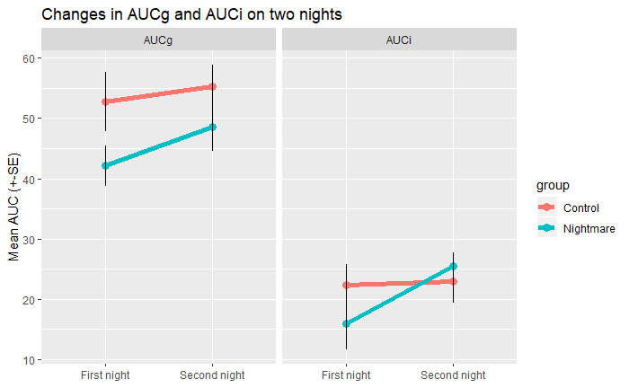

```r
cort_auc %>%
    group_by(group, day) %>%
    summarise(AUCi_mean = mean(auc_i, na.rm = TRUE),
              AUCi_se = sd(auc_i, na.rm = TRUE)/sqrt(n()),
              AUCg_mean = mean(auc_g, na.rm = TRUE),
              AUCg_se = sd(auc_g, na.rm = TRUE)/sqrt(n())
            ) %>%
    ungroup() %>%
    gather(metric, value, -group, -day) %>%
    separate(metric, c("type", "stat"), sep = "_") %>%
    spread(stat, value) %>%
    ggplot() +
        aes(x = day,
            y = mean,
            ymin = mean - se,
            ymax = mean + se,
            group = group) +
        geom_line(aes(color = group), size = 1.8) +
        geom_point(aes(color = group), size = 3) +
        geom_linerange() +
        facet_wrap(~type) +
        labs(title = "Changes in AUCg and AUCi on two nights",
             y = "Mean AUC (+-SE)",
             x = NULL)
```

### AUCg

The day was a significant predictor of AUCg, whereas the second night was associated with slightly higher AUCg than the first. There were no differences between the groups.

```r
aucg_lm <- lm(auc_g ~ group * day, data = cort_auc)
aucg_i <- lmer(auc_g ~ group * day + (1|id), data = cort_auc)
# anova(aucg_i, aucg_lm)
aucg_best <- aucg_i
aucg_2_1 <- update(aucg_best, . ~ . - group : day) # Drop
# anova(aucg_best, aucg_2_1)
aucg_best <- aucg_2_1
aucg_1_1 <- update(aucg_best, . ~ . - group) # Drop
aucg_1_2 <- update(aucg_best, . ~ . - day) # Keep
# anova(aucg_best, aucg_1_1)
# anova(aucg_best, aucg_1_2)
aucg_best <- aucg_1_1
summary(aucg_best)
```

```
Linear mixed model fit by REML. t-tests use Satterthwaite's method [
lmerModLmerTest]
Formula: auc_g ~ day + (1 | id)
   Data: cort_auc

REML criterion at convergence: 607.1

Scaled residuals:
     Min       1Q   Median       3Q      Max
-1.80943 -0.41655  0.07471  0.38205  1.88063

Random effects:
 Groups   Name        Variance Std.Dev.
 id       (Intercept) 245.2    15.660
 Residual              67.5     8.216
Number of obs: 76, groups:  id, 38

Fixed effects:
                Estimate Std. Error     df t value Pr(>|t|)
(Intercept)       46.868      2.869 45.822  16.337   <2e-16 ***
daySecond night    4.632      1.885 37.000   2.457   0.0188 *
---
Signif. codes:  0 ‘***’ 0.001 ‘**’ 0.01 ‘*’ 0.05 ‘.’ 0.1 ‘ ’ 1

Correlation of Fixed Effects:
            (Intr)
dayScndnght -0.329
```

### AUCi

There was no effect of the predictors on AUCi.

```r
auci_lm <- lm(auc_i ~ group * day, data = cort_auc)
auci_i <- lmer(auc_i ~ group * day + (1|id), data = cort_auc)
# anova(auci_i, auci_lm)
auci_best <- auci_i
auci_2_1 <- update(auci_best, . ~ . - group : day) # Drop
# anova(auci_best, auci_2_1)
auci_best <- auci_2_1
auci_1_1 <- update(auci_best, . ~ . - group) # Drop
auci_1_2 <- update(auci_best, . ~ . - day) # Drop
# anova(auci_best, auci_1_1)
# anova(auci_best, auci_1_2)
summary(auci_i)
```

```
Linear mixed model fit by REML. t-tests use Satterthwaite's method [
lmerModLmerTest]
Formula: auc_i ~ group * day + (1 | id)
   Data: cort_auc

REML criterion at convergence: 604.2

Scaled residuals:
    Min      1Q  Median      3Q     Max
-4.0127 -0.4497  0.0274  0.5709  1.9046

Random effects:
 Groups   Name        Variance Std.Dev.
 id       (Intercept)  81.77    9.043
 Residual             152.39   12.345
Number of obs: 76, groups:  id, 38

Fixed effects:
                               Estimate Std. Error      df t value Pr(>|t|)
(Intercept)                     22.4118     3.7114 64.1746   6.039 8.63e-08
groupNightmare                  -6.4118     4.9925 64.1746  -1.284    0.204
daySecond night                  0.5588     4.2342 36.0000   0.132    0.896
groupNightmare:daySecond night   8.8936     5.6958 36.0000   1.561    0.127

(Intercept)                    ***
groupNightmare
daySecond night
groupNightmare:daySecond night
---
Signif. codes:  0 ‘***’ 0.001 ‘**’ 0.01 ‘*’ 0.05 ‘.’ 0.1 ‘ ’ 1

Correlation of Fixed Effects:
            (Intr) grpNgh dyScnn
groupNghtmr -0.743
dayScndnght -0.570  0.424
grpNghtm:Sn  0.424 -0.570 -0.743
```